# Sampling Distribution Demo 2 (proportions)

Author

Bárbara D. Bitarello

Published

November 3, 2026

Modified

November 16, 2026

In class, we had everyone sample 5 frogs randomly with replacement from a bag containing 145 plastic frogs, of which 27 were green. In each case we recorded how many green frogs were sampled (in a sample of 5). We did this 40 times. The column `P_green` is simply the number of green frogs observed divided by the sample size.

Let’s read in the results:

```r
library(tidyverse)


frogs<-read_csv("Sampling-distribution-activity-n-5.csv")
frogs |> head()
```

```
# A tibble: 6 × 4
  Replicate sample_size nr_green_frogs P_green
      <dbl>       <dbl>          <dbl>   <dbl>
1         1           5              1     0.2
2         2           5              1     0.2
3         3           5              1     0.2
4         4           5              1     0.2
5         5           5              1     0.2
6         6           5              1     0.2
```

We can quickly assess which outcomes were most common:

```r
frogs |> group_by(nr_green_frogs) |> tally()
```

```
# A tibble: 4 × 2
  nr_green_frogs     n
           <dbl> <int>
1              0    13
2              1    18
3              2     8
4              3     1
```

Is this unexpected? We said above that the bag had 27 green frogs, so let’s compare our estimates (variable) to the parameter (not variable):

```r
samp_size <- 5 #our sample size
real_p <- 27/145
exp_green <- real_p*samp_size #expected nr of greens in a sample of 5
exp_green #0.93, which is not an integer. The closest integer is 1 frog
```

```
[1] 0.9310345
```

So our expected number of green frogs in samples of this size is 0.93, which is not an integer. The closest integer is 1. In our samples we saw that 1 green frog was the most frequent outcome, which confirms our intuition.

Let’s plot this. The dotted orange line shows the expected number of green frogs.

```r
# difference between my grand mean and the real expected nr of green frogs is tiny:
mymean<-mean(frogs$nr_green_frogs)
round(mymean-exp_green,2)
```

```
[1] -0.01
```

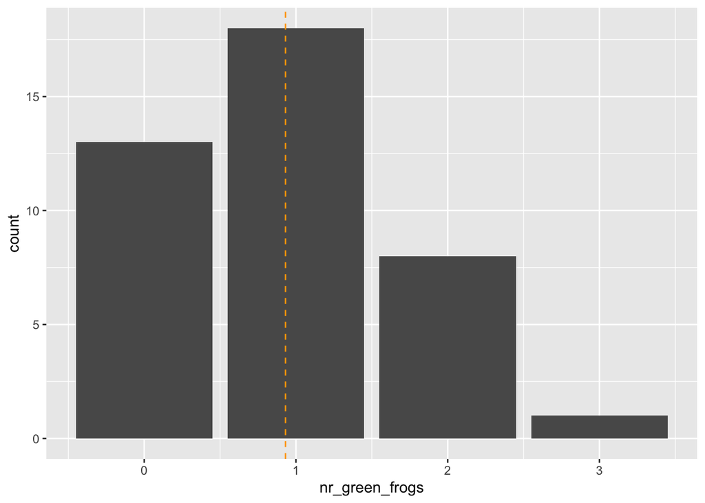

```r
p1<-frogs |>
  ggplot(aes(x = nr_green_frogs)) +
  geom_bar() +
  geom_vline(aes(xintercept = exp_green), lty = 2, col = "orange" )
p1
```

We only did this 40 times. What if we could simulate what we did in class many, many times?

```r
nreps <- 10000 # nr of replicates
# create vector for results
results<-vector('list', nreps)

frog<-c("green", "notGreen")
p_green<-27/145
p_notG<-(145-27)/145

samp_size <- 5 #our sample size.

for( i in 1:nreps){
  results[[i]]<-sample(frog, size = samp_size, replace = T, prob = c(p_green, p_notG))
}

# clean this up a bit
results2<-c()

for( i in 1:nreps){
  results2[i]<-sum(results[[i]] == "green")

}

df <- data.frame(replicate = 1:nreps, nr_green_frogs = results2, sample_size = samp_size)

myMean2<-mean(df$nr_green_frogs)
# difference my grand mean and expected nr of green frogs:
round(myMean2-exp_green,2)
```

```
[1] -0.01
```

Great,now we can plot again:

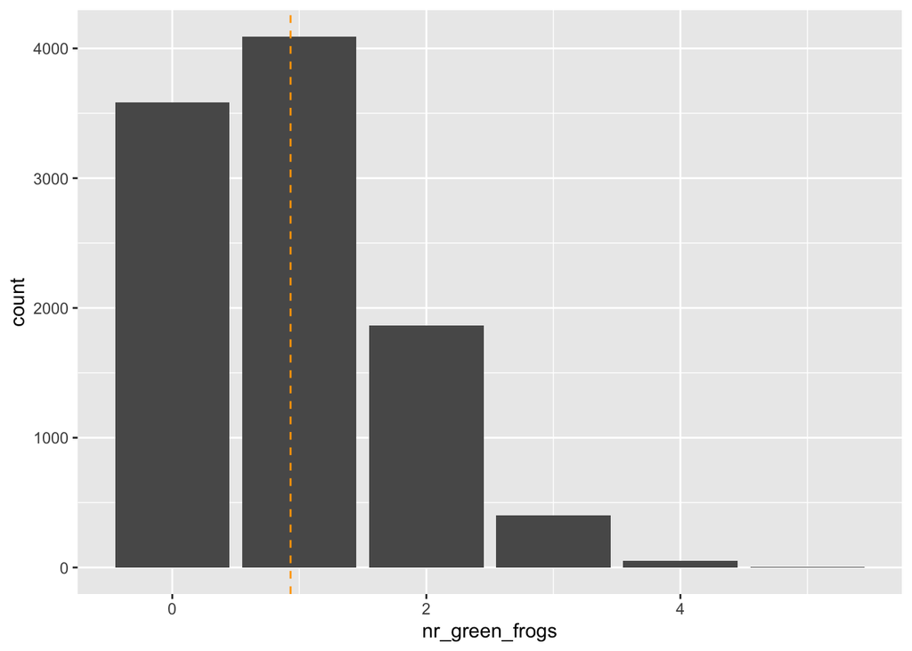

```r
p2<-df |>
  ggplot(aes(x = nr_green_frogs)) +
  geom_bar() +
  geom_vline(aes(xintercept = exp_green), lty = 2, col = "orange" )
p2
```

Now here’s a generic chunk you can play with. You can increase the sample_size and see what happens.

```r
##### This part doesn't change
frog<-c("green", "notGreen")
p_green<-27/145
p_notG<-(145-27)/145
######
# this you can change, but you don't need to mess with the nr of replicates. This nr is plenty.

nreps <- 10000 # nr of replicates

samp_size <- 20 # Start with this. Comapre it to our previous plot. Then play around with this and re-run the code to see the differences.

exp_green <- p_green * samp_size
# create vector for results
results<-vector('list', nreps)
results2<-c()
#########################

# now we sample:

for( i in 1:nreps){
  results[[i]]<-sample(frog, size = samp_size, replace = T, prob = c(p_green, p_notG))
  results2[i]<-sum(results[[i]] == "green")
}
# clear up some space
remove(results)

# make a df
df2 <- data.frame(replicate = 1:nreps, nr_green_frogs = results2, sample_size = samp_size)

myMeanSim<-mean(df2$nr_green_frogs)
# difference my grand mean and expected nr of green frogs:
round(myMeanSim-exp_green,2)
```

```
[1] 0.02
```